Ullrich Köthe: Fundamentals of Machine Learning, Winter Semester 2020/21  
Notebook created by Lorenzo Cerrone, modified by Elias Arnold at 09.12.2020

# Solutions for Exercise 2

```python
import sklearn
from sklearn.datasets import load_digits
from sklearn.model_selection import train_test_split, cross_val_score
import numpy as np
%matplotlib inline
import matplotlib.pyplot as plt

# You can globally change the styling of your plots
plt.rcParams['axes.labelsize'] = 12
plt.rcParams['axes.labelweight'] = 'bold'
plt.rcParams['axes.titlesize'] = 16
plt.rcParams['axes.titleweight'] = 'bold'
```

# 3 Data Preparation

```python
def train_test_split(data, target, test_size=0.3, random_state=0):
    """
    Randomize given data set and split in test and training set.
    """
    # Get test size
    test_size = int(data.shape[0] * test_size)

    # Set seed
    np.random.seed(random_state)

    # Permutation
    p = np.random.permutation(data.shape[0])
    test_p = p[:test_size]
    train_p = p[test_size:]

    return data[train_p], data[test_p], target[train_p], target[test_p]
```

```python
def data_preparation(digits, test_percentage = 0.33, random_seed=0):
    """
    This function filters the digits (1, 7) from the dataset and randomly splits it in train and test set.
    """
    data = digits["data"]
    target = digits["target"]

    # Data filering
    num_1, num_2 = 1, 7
    mask = np.logical_or(target == num_1, target == num_2)
    data = data[mask]/data.max()
    target = target[mask]

    # Relabel targets
    target[target == num_1] = 0
    target[target == num_2] = 1

    # Random split
    x_training, x_test, y_training, y_test = train_test_split(data, target, test_size=test_percentage,
                                                                      random_state=random_seed)


    return x_training, x_test, y_training, y_test
```

## 3.1 Dimension Reduction

```python
def reduce_dim(x):
    """
    Perform a user defined dimension reduction
    input: N x 64 numpy array
    output: N x 2 numpy array
    """
    # mean(Upper part) - mean(Lower part)
    feat1 = (np.mean(x[:, :x.shape[-1]//4], axis=-1) -
             np.mean(x[:, 3 * x.shape[-1]//4:], axis=-1))

    # mean(Upper part) * mean(Lower part)
    feat2 = (np.mean(x[:, :x.shape[-1]//4] * x[:, 3 * x.shape[-1]//4:], axis=-1))

    return np.array([feat1, feat2]).T

def worse_reduce_dim(x):
    """
    Perform a user defined dimension reduction
    input x: N x 64 numpy array
    output: N x 2 numpy array
    """
    # mean(Image)
    feat1 = np.mean(x, axis=-1)

    # var(Image)
    feat2 = np.var(x, axis=-1)

    return np.array([feat1, feat2]).T
```

# 3.2 Scatter Plot

```python
def scatter_plot_simple(x, y, title="Training"):
    """
    This function returns the dataset scatter plot
    input x: N x 2 numpy array
    input y: N x 1 numpy array
    output: None
    """
    plt.figure(figsize=(16, 9))
    plt.title(title + " Scatter Plot: 1 vs 7")

    # Scatter plot
    plt.scatter(x[y == 0, 0], x[y == 0, 1], marker="o", s=30, c="b", label= "1")
    plt.scatter(x[y == 1, 0], x[y == 1, 1], marker="x", s=30, c="r", label= "7")

    plt.xlabel("feature 1")
    plt.ylabel("feature 2")
    plt.legend()
    plt.show()
```

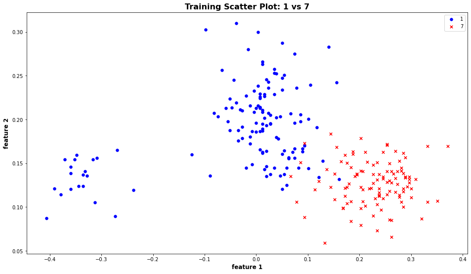

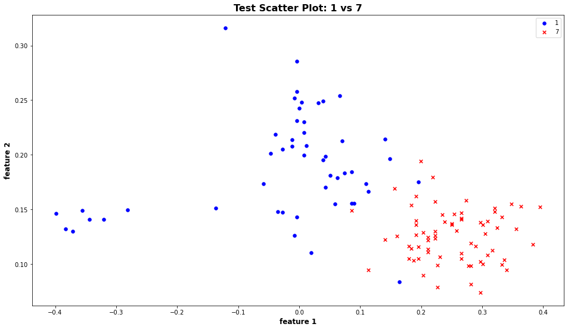

```python
# Load data
digits = load_digits()

# Filering data
x_training, x_test, y_training, y_test = data_preparation(digits, 0.33, 0)

# Dimension Reduction
xr_training, xr_test = reduce_dim(x_training), reduce_dim(x_test)

# Scatter Plot
scatter_plot_simple(xr_training, y_training, "Training")
scatter_plot_simple(xr_test, y_test, "Test")
```

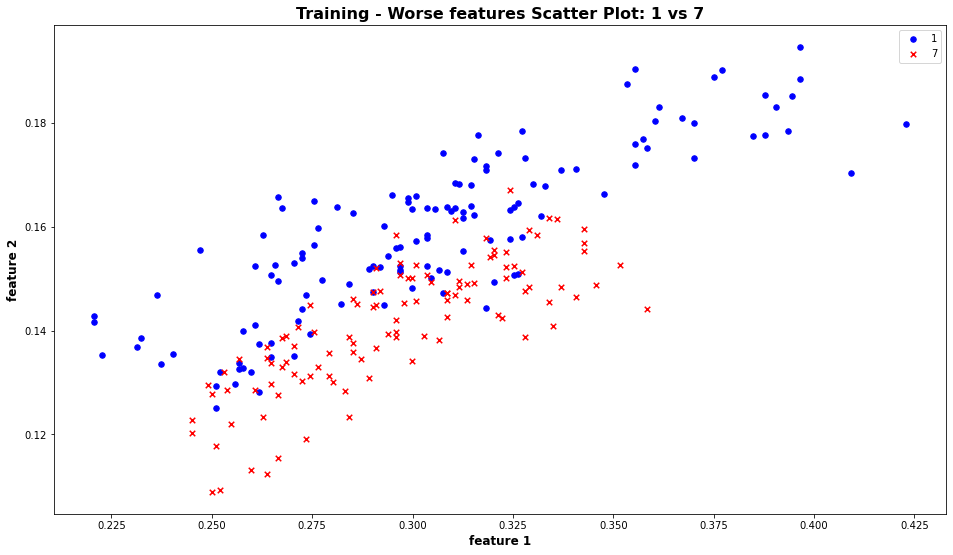

```python
# Dimension Reduction
_xr_training, _xr_test = worse_reduce_dim(x_training), worse_reduce_dim(x_test)

# Scatter Plot
scatter_plot_simple(_xr_training, y_training, "Training - Worse features")
```

# 4 Nearest Mean

# 4.1 Implement the nearest mean classifier

```python
# Compute the distance of a vector x from a mean point
def distance_from_mean(x, mean):
    """
    Computes the L2-distance
    """
    return np.sqrt(np.sum((x - mean)**2, axis=-1))

def nearest_mean(training_features, training_labels, test_features):
    """
    This function returns the nearest mean predictions given
    input training_features: N_training x 2 numpy array
    input training_labels: N_training x 1 numpy array
    input test_features: N_test x 2 numpy array
    output: test_predictions: N_test numpy array
    """

    classes_list = np.unique(training_labels)
    mean_points = []
    # Find all mean points
    for label in classes_list:
        mean_points.append(np.mean(training_features[training_labels == label], axis=0))


    distance2mean = np.zeros((test_features.shape[0],
                              classes_list.shape[0]))
    # Compute the distances between test_features and all mean
    for label in classes_list:
        distance2mean[:, label] = distance_from_mean(test_features, mean_points[label])

    return np.argmin(distance2mean, axis=-1), mean_points
```

```python
# Dimension Reduction
xr_test =  reduce_dim(x_test)

# Find Nearest Mean Predictions
predicted_labels_test, mean_points = nearest_mean(xr_training, y_training, xr_test)
predicted_labels_train, _ = nearest_mean(xr_training, y_training, xr_training)

# Print accuracy
print("Test accuracy Nearest Mean: ", np.mean(predicted_labels_test == y_test))
print("Training accuracy Nearest Mean: ", np.mean(predicted_labels_train == y_training))
```

```
Test accuracy Nearest Mean:  0.9411764705882353
Training accuracy Nearest Mean:  0.9545454545454546
```

# 4.2 Visualize the decision regions

```python
def visualization_NearestMean(xr_train, y_train, xr_test, y_test):
    """
    This Function visualizes the decision regions for the Nearest Mean Classifier
    """
    # Build Grid
    feat_min, feat_max = np.min(xr_test, axis=0), np.max(xr_test, axis=0)
    x, y = np.linspace(feat_min[0], feat_max[0], 2000), np.linspace(feat_max[1], feat_min[1], 2000)
    xx = np.array(np.meshgrid(x, y)).reshape(2, -1).T

    # Predict grid labels
    predicted_labels, mean_points = nearest_mean(xr_train, y_train, xx)

    # Decison boundary
    plt.figure(figsize=(16, 9))
    plt.title("Decision Regions (Blue: 1, Red: 7)")
    plt.imshow(predicted_labels.reshape(-1, 2000),
               cmap="prism_r", alpha=0.2, vmin=-5,
               extent=(feat_min[0], feat_max[0], feat_min[1], feat_max[1]))

    # Scatter data
    plt.scatter(xr_test[y_test == 0, 0], xr_test[y_test == 0, 1], marker="o", s=30, c="b", label= "1")
    plt.scatter(xr_test[y_test == 1, 0], xr_test[y_test == 1, 1], marker="x", s=30, c="r", label= "7")

    # Scatter mean points
    plt.scatter(mean_points[0][0], mean_points[0][1], marker="o", s=50, c="g", label= "Mean")
    plt.scatter(mean_points[1][0], mean_points[1][1], marker="o", s=50, c="g")

    plt.xlim(feat_min[0], feat_max[0])
    plt.ylim(feat_min[1], feat_max[1])

    plt.xlabel("feature 1")
    plt.ylabel("feature 2")
    plt.legend()
    plt.show()
```

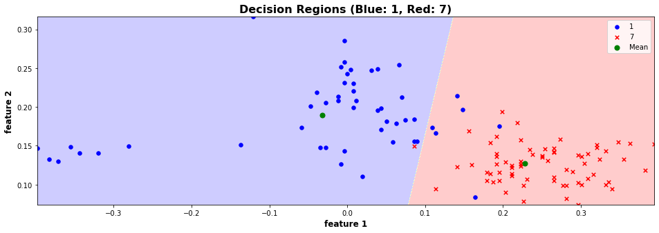

```python
visualization_NearestMean(xr_training, y_training, xr_test, y_test)
```

# 5 QDA

## 5.1 Implement QDA Training

```python
def fit_qda(training_features, training_labels):
    """
    This function compute for each class: mean, covariance matrix and priors

    input training_features: N_training x 2 numpy array
    input training_labels: N_training x 1 numpy array
    output: mu: N_labels x 2
    output: cov: N_labels x 2 x 2
    output: p: N_labels x 1
    """
    mu, cov, p = [], [], []
    for label in np.unique(training_labels):
        # filtering the correct class
        data = training_features[training_labels == label]

        # mean
        mean = np.mean(data, axis=0)
        mu.append(mean)

        # Covariance
        # Computed as in textbook
        # data_centered = data - mean
        # cov.append(np.dot(data_centered.T, data_centered)/data.shape[0])

        # as numpy oneliner
        cov.append(np.cov(data.T))

        # Prior
        p.append(data.shape[0]/training_features.shape[0])

    return mu, cov, p
```

## 5.2 Implement QDA Prediction

```python
def log_likelihood(x, mu, cov, p):
    """
    This function returns the log-likelihood for each data point x

    input x: N x 2 numpy array
    input: mu: 2 numpy array
    input: cov: 2 x 2 numpy array
    input: p: 1 float
    output logl: N x 2 numpy array
    """
    b = - 0.5 * np.log(np.linalg.det(2 * np.pi * cov)) + np.log(p)
    x = x - mu
    logl = -0.5 * (np.sum(x.T * np.dot(np.linalg.inv(cov), x.T), axis=0)) + b
    return logl

def predict_qda(mu, cov, p, test_features):
    """
    This function returns the QDA predictions given
    input test_features: N_test x 2 numpy array
    output: test_predictions: N_test numpy array
    """
    loglikelihood = np.zeros((test_features.shape[0], len(mu)))

    # Find the loglikelihood for each test point
    for label in range(len(mu)):
        loglikelihood[:, label] = log_likelihood(test_features,
                                                 mu[label],
                                                 cov[label],
                                                 p[label])
    return np.argmax(loglikelihood, axis=-1)
```

```python
# Fit QDA
mu, cov, p = fit_qda(xr_training, y_training)

# Find QDA Predictions
predicted_labels_test = predict_qda(mu, cov, p, xr_test)
predicted_labels_train = predict_qda(mu, cov, p, xr_training)

# Print accuracy
print("Test accuracy QDA: ", np.mean(predicted_labels_test == y_test))
print("Training accuracy QDA: ", np.mean(predicted_labels_train == y_training))
```

```
Test accuracy QDA:  0.9663865546218487
Training accuracy QDA:  0.9669421487603306
```

## 5.3 Visualization

```python
def plot_ellipse_axis(mu, cov, color="blue"):
    """
    This function plots the main axis of the distribution given mean and covariance matrix
    """

    # Eigenvalues/Eigenvector decomposition
    [lamb1, lamb2], [vec_1, vec_2] = np.linalg.eig(cov)
    lamb1, lamb2 = np.sqrt(lamb1), np.sqrt(lamb2)

    # Plot axis 1
    x1, y1 = ([mu[0] - lamb1*vec_1[0], mu[0] + lamb1*vec_1[0]],
              [mu[1] - lamb1*vec_2[0], mu[1] + lamb1*vec_2[0]])
    plt.plot(x1, y1, color)

    # Plot axis 2
    x2, y2 = ([mu[0] - lamb2*vec_1[1], mu[0] + lamb2*vec_1[1]],
              [mu[1] - lamb2*vec_2[1], mu[1] + lamb2*vec_2[1]])
    plt.plot(x2, y2, color)

def visualization_QDA(xr_train, y_train, xr_test, y_test, simple=True):
    """
    This Function visualizes the decision regions for the QDA Classifier
    """
    # Build Grid
    feat_min, feat_max = np.min(xr_test, axis=0), np.max(xr_test, axis=0)

    x, y = np.linspace(feat_min[0], feat_max[0], 200), np.linspace(feat_max[1], feat_min[1], 200)
    xx = np.array(np.meshgrid(x, y)).reshape(2, -1).T

    # Predict grid labels
    predicted_labels = predict_qda(mu, cov, p, xx)

    # Decison boundary
    plt.figure(figsize=(16, 9))
    plt.title("Decision Regions (Blue: 1, Red: 7)")
    plt.imshow(predicted_labels.reshape(-1, 200),
               cmap="prism_r",
               alpha=0.2, vmin=-5,
               extent=(feat_min[0], feat_max[0], feat_min[1], feat_max[1]))

    # Scatter data
    plt.scatter(xr_test[y_test == 0, 0], xr_test[y_test == 0, 1], marker="o", s=30, c="b", label= "1")
    plt.scatter(xr_test[y_test == 1, 0], xr_test[y_test == 1, 1], marker="x", s=30, c="r", label= "7")

    # Scatter mean points
    plt.scatter(mean_points[0][0], mean_points[0][1], marker="o", s=50, c="g", label= "Mean")
    plt.scatter(mean_points[1][0], mean_points[1][1], marker="o", s=50, c="g")

    # if simple == False add isocontours and clusters axiss
    if not simple:
        zz = np.exp(log_likelihood(xx, mu[0], cov[0], p[0]))
        plt.contour(x, y, zz.reshape(-1, 200), 3, colors='blue')

        zz = np.exp(log_likelihood(xx, mu[1], cov[1], p[1]))
        plt.contour(x, y, zz.reshape(-1, 200), 3, colors='red')

        plot_ellipse_axis(mu[0], cov[0], color="green")
        plot_ellipse_axis(mu[1], cov[1], color="green")

    plt.xlim(feat_min[0], feat_max[0])
    plt.ylim(feat_min[1], feat_max[1])

    plt.xlabel("feature 1")
    plt.ylabel("feature 2")
    plt.legend()
    plt.show()
```

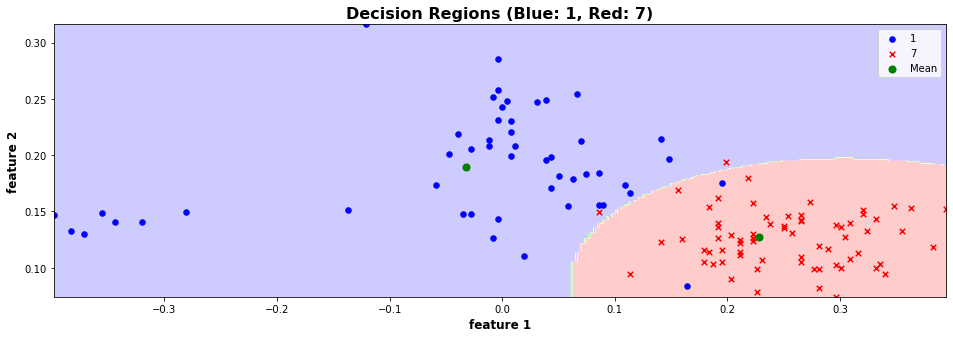

```python
visualization_QDA(xr_training, y_training, xr_test, y_test, simple=True)
```

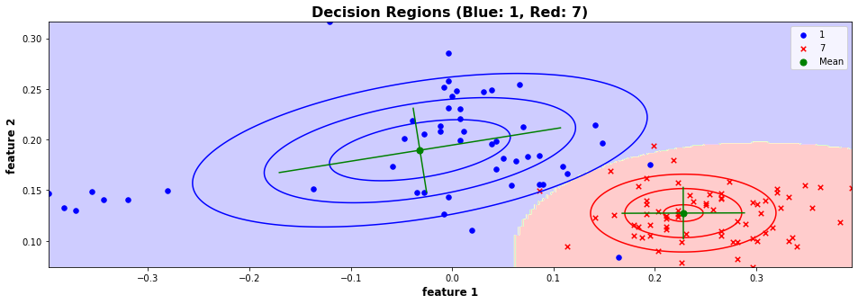

```python
visualization_QDA(xr_training, y_training, xr_test, y_test, simple=False)
```

The training error of the nearest neighbor classifier is always zero, because an sample of the training set will always be classified by its own target value since the distance to itself is always zero.

QDA assumes the likelihoods of the data set to be gaussian distributions with a class specific covariance. By doing bayesian-optimal inference, the decision boundary is then given by the set $\lbrace x \rbrace$ for which \begin{align} p(y=1|x) &= p(y=7|x) = \tfrac{1}{2} \\ \frac{p(y=1) p(x|y=1)}{p(x)} &= \frac{p(y=7) p(x|y=7)}{p(x)} \\ p(x|y=1) &= p(x|y=7) \\ \end{align} holds as $p(y=1) = p(y=7)$. Here, the likelihoods are given by: \begin{align} p(x|y=k) = \mathcal N(x|\Sigma_k, \mu_k) = \frac{1}{\sqrt{\det 2\pi\Sigma_k}} \exp \left(-\frac{1}{2}(x-\mu_k)^\top \Sigma^{-1}_k(x-\mu_k)\right), \end{align}

By using QDA to model the likelihood $p(x|y)$, we made an assumption about its shape and discarded the information about the individual training samples. Thus we can also not expect each training sample to be classified like labeled.

Instead, QDA assigns each $x$ *softly* to the different labels: The class specific likelihood (for instance $p(x|y=1)$) is still greater than zero outside of its own decision region, i.e. outside of where $y=1$ gets predicted. Thus training instances are expected to occur there. In contrast, the nearest neigbour classifier assigns the traning/test instances to "hard" clusters.

Note the special case where $\Sigma_k = \mathbf{1}\sigma ^2$: The exponential term becomes the Euclidean distance turning QDA into the nearest mean classifier (assuming $N_k$ are equal for all $k$), meaning the gausian distributions have a spherical covariance. Since the term \begin{align} (x-\mu_k)^\top \Sigma^{-1}_k(x-\mu_k) \end{align} is called the $\textbf{Mahalanobis distance}$, QDA is said to be the nearest mean classifier under Mahalanobis distance.

## 5.4 Performance Evaluation

### Manual implementation

```python
from sklearn.model_selection import KFold

def cross_validation(digits, fit_func, pred_func, num_sample=10):
    """
    Measure the correct accuracy with cross validation
    """
    # Get data
    data = digits["data"]
    target = digits["target"]

    # Need to prepare data again since 'data_preparation' returns test - train split
    # Data filering
    num_1, num_2 = 1, 7
    mask = np.logical_or(target == num_1, target == num_2)
    data = data[mask]/data.max()
    target = target[mask]

    # Relabel targets
    target[target == num_1] = 0
    target[target == num_2] = 1

    # Splits
    k_folds = KFold(n_splits=num_sample)

    mean_rate = np.zeros(num_sample)
    for i, (train, test) in enumerate(k_folds.split(data)):
        xr_train, xr_test = reduce_dim(data[train]), reduce_dim(data[test])
        mu, cov, p = fit_func(xr_train, target[train])
        predicted_labels = pred_func(mu, cov, p, xr_test)
        mean_rate[i] = np.mean(predicted_labels == target[test])

    print("Mean Accuracy Cross Validation: %f +/- %f"%(np.mean(mean_rate), np.std(mean_rate)))
```

```python
# Digits
digits = load_digits()
# Print Cross validation accuracy
cross_validation(digits, fit_qda, predict_qda, 100)
```

```
Mean Accuracy Cross Validation: 0.966667 +/- 0.097895
```

# 6 LDA

```python
def fit_lda(training_features, training_labels):
    """
    This function compute for each class: mean and priors, and the global covariance matrix

    input training_features: N_training x 2 numpy array
    input training_labels: N_training x 1 numpy array
    output lists of means, covariances and priors
    """
    mu, cov, p = [], [], []
    for label in np.unique(training_labels):
        # filtering the correct class
        data = training_features[training_labels == label]

        # mean
        mean = np.mean(data, axis=0)
        mu.append(mean)

        # Priors
        p.append(data.shape[0]/training_features.shape[0])

    # Global Variance, subtract class means first

    # computed as in texbook
    # global_feat = training_features - np.array(mu)[training_labels]
    # np.mean(training_features, axis=0)
    # cov = np.dot(global_feat.T, global_feat)/training_features.shape[0]

    # as numpy oneliner
    cov = np.cov(training_features.T)
    return mu, cov, p

def predict_lda(mu, cov, p, test_features):
    """
    This function returns the LDA predictions given
    as input lists of means, priors and the global covariance matrix
    input test_features: N_test x 2 numpy array
    output: test_predictions: N_test numpy array
    """
    loglikelihood = np.zeros((test_features.shape[0], len(mu)))

    # Find the loglikelihood for each test point
    for label in range(len(mu)):
        loglikelihood[:, label] = log_likelihood(test_features,
                                                 mu[label],
                                                 cov,
                                                 p[label])
    return np.argmax(loglikelihood, axis=-1)

def visualization_LDA(xr_train, y_train, xr_test, y_test, simple=True):
    """
    This Function visualizes the decision regions for the LDA Classifier
    """
    # Build Grid
    feat_min, feat_max = np.min(xr_test, axis=0), np.max(xr_test, axis=0)
    x, y = np.linspace(feat_min[0], feat_max[0], 200), np.linspace(feat_max[1], feat_min[1], 200)
    xx = np.array(np.meshgrid(x, y)).reshape(2, -1).T

    # Predict grid labels
    predicted_labels = predict_lda(mu, cov, p, xx)

    plt.figure(figsize=(16, 9))
    plt.title("Decision Regions (Blue: 1, Red: 7)")
    plt.imshow(predicted_labels.reshape(-1, 200),
               cmap="prism_r", alpha=0.2, vmin=-5,
               extent=(feat_min[0], feat_max[0], feat_min[1], feat_max[1]))

    # Scatter data
    plt.scatter(xr_test[y_test == 0, 0], xr_test[y_test == 0, 1], marker="o", s=30, c="b", label= "1")
    plt.scatter(xr_test[y_test == 1, 0], xr_test[y_test == 1, 1], marker="x", s=30, c="r", label= "7")

    # Scatter Mean
    plt.scatter(mean_points[0][0], mean_points[0][1], marker="o", s=50, c="g", label= "Mean")
    plt.scatter(mean_points[1][0], mean_points[1][1], marker="o", s=50, c="g")

    # if simple == False add isocontours and clusters axiss
    if not simple:
        zz = np.exp(log_likelihood(xx, mu[0], cov, p[0]))
        plt.contour(x, y, zz.reshape(-1, 200), 3, colors='blue')

        zz = np.exp(log_likelihood(xx, mu[1], cov, p[1]))
        plt.contour(x, y, zz.reshape(-1, 200), 3, colors='red')

        plot_ellipse_axis(mu[0], cov, color="green")
        plot_ellipse_axis(mu[1], cov, color="green")

    plt.xlim(feat_min[0], feat_max[0])
    plt.ylim(feat_min[1], feat_max[1])

    plt.xlabel("feature 1")
    plt.ylabel("feature 2")
    plt.legend()
    plt.show()
```

```python
# Fit LDA
mu, cov, p = fit_lda(xr_training, y_training)

# Find QDA Predictions
predicted_labels_test = predict_lda(mu, cov, p, xr_test)
predicted_labels_train = predict_lda(mu, cov, p, xr_training)

# Print accuracy
print("Test accuracy LDA: ", np.mean(predicted_labels_test == y_test))
print("Training accuracy LDA: ", np.mean(predicted_labels_train == y_training))
```

```
Test accuracy LDA:  0.957983193277311
Training accuracy LDA:  0.9586776859504132
```

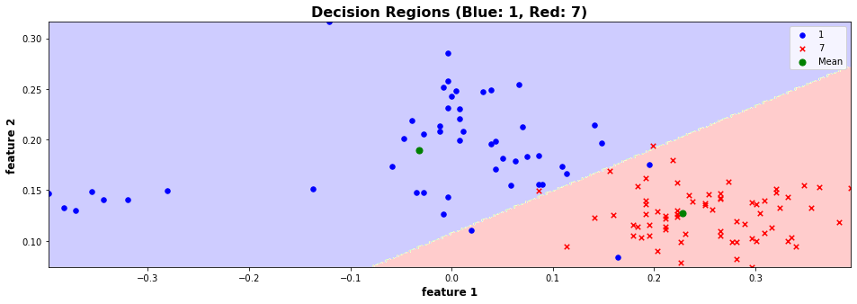

```python
visualization_LDA(xr_training, y_training, xr_test, y_test, simple=True)
```

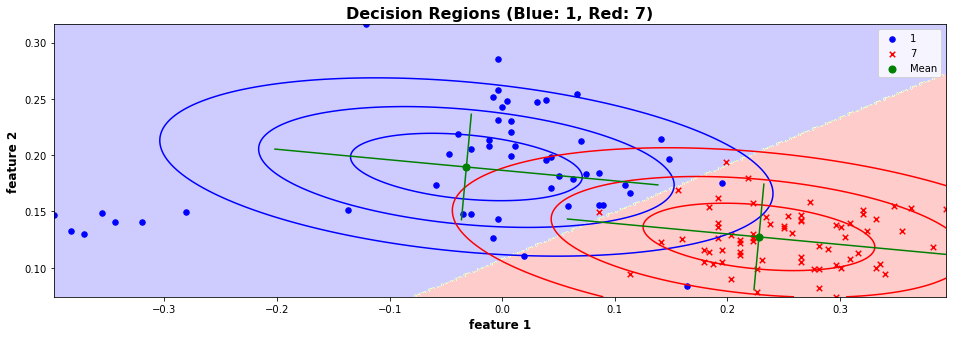

```python
visualization_LDA(xr_training, y_training, xr_test, y_test, simple=False)
```

```python
cross_validation(digits, fit_lda, predict_lda, 100)
```

```
Mean Accuracy Cross Validation: 0.960833 +/- 0.104386
```

The interpretation of the misclassification of training instances is the same as for QDA. The only difference is that the likelihoods for LDA share the exact same covariance matrix.